# P1.6 - Aprendizaje supervisado

SSPIAII_Equipo4

2024-03-05

# Integrantes:

1. Gómez Plascencia Waldo.
2. Ascencio Padilla Isaac Ulises.
3. Vidrio Lizaola Alfonso Manuel.
4. Becerra Ramírez Alejandro.
5. Aceves Díaz César Alejandro.

## Bases teórico-matematicas y Funcionamiento

El Gradient Boosting funciona mediante la creación de árboles de decisión secuenciales, donde cada árbol se enfoca en corregir los errores del modelo anterior1. En la primera iteración, se crea un árbol de decisión que minimiza los errores del modelo inicial. Luego, en cada iteración subsiguiente, se crea un nuevo árbol que se enfoca en los residuos (es decir, los errores) del modelo anterior. Este proceso se repite hasta que se alcanza un número predefinido de árboles (especificado por el parámetro n.trees en la función gbm()) o hasta que los errores ya no se pueden reducir significativamente.

## Matriz de Correlación

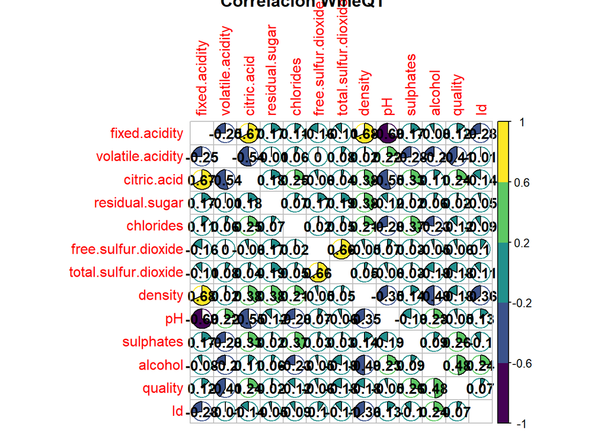

```r
source("Lib.Preprocess.R")
df.Wine <- read.csv(file = "WineQT.csv", header  = T, stringsAsFactors = F)

#Matriz de correlación.
cor.Wine <- cor(df.Wine)
corrplot(cor.Wine,
        addCoef.col = "black",
        insig = "label_sig",
        method = "pie",
        type = "full",
        diag = F,
        col = viridis(n = 5, direction = 1),
        title = "Correlación WineQT")
```

## Modelos

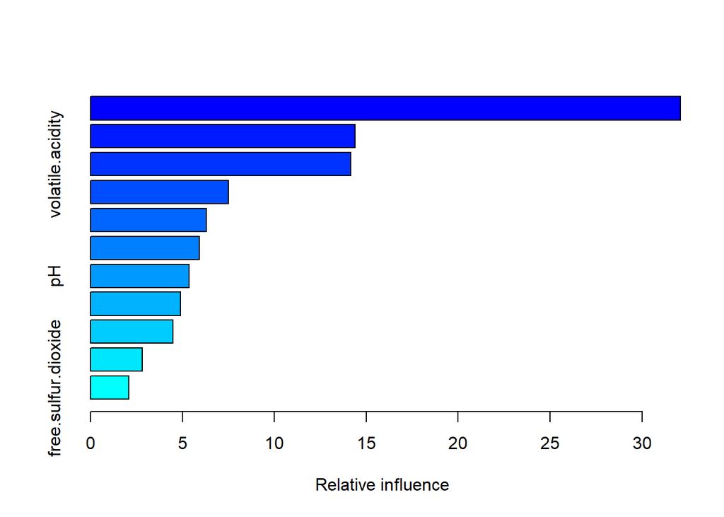

```
##                                       var   rel.inf
## alcohol                           alcohol 32.087106
## sulphates                       sulphates 14.401983
## volatile.acidity         volatile.acidity 14.144905
## total.sulfur.dioxide total.sulfur.dioxide  7.495550
## citric.acid                   citric.acid  6.317111
## density                           density  5.918753
## pH                                     pH  5.366171
## fixed.acidity               fixed.acidity  4.895187
## chlorides                       chlorides  4.485383
## residual.sugar             residual.sugar  2.810611
## free.sulfur.dioxide   free.sulfur.dioxide  2.077241
```

```r
source("Lib.Preprocess.R")
set.seed(1991)
options(scipen = 999)
df.Wine <- read.csv(file = "WineQT.csv", header  = T, stringsAsFactors = F)
df.Wine$Id <-NULL

#Entrenamiento y prueba
Split <- sample.split(Y = df.Wine$alcohol, SplitRatio = 0.8)
df.Wine.Train <- subset(df.Wine, Split == T)
df.Wine.Test <- subset(df.Wine, Split == F)

gbm.fit <- gbm(quality ~ ., data = df.Wine.Train, distribution = "gaussian", n.trees = 1000, interaction.depth = 3, shrinkage = 0.01, cv.folds = 5, verbose = T)
summary(gbm.fit)
```

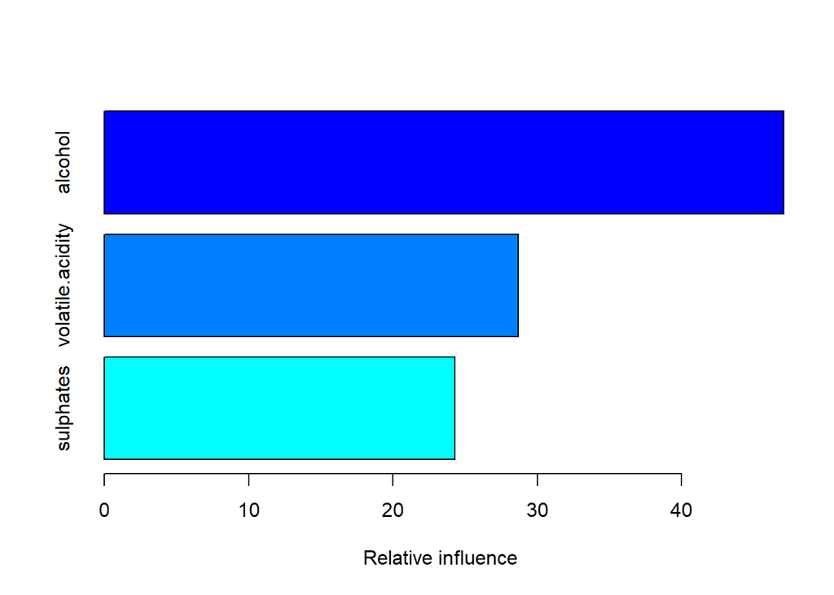

```
##                               var  rel.inf
## alcohol                   alcohol 47.06779
## volatile.acidity volatile.acidity 28.65958
## sulphates               sulphates 24.27263
```

```r
gbm.fit2 <- gbm(quality ~ alcohol + volatile.acidity + sulphates, data = df.Wine.Train, distribution = "gaussian", n.trees = 1000, interaction.depth = 3, shrinkage = 0.01, cv.folds = 5, verbose = T)
summary(gbm.fit2)
```

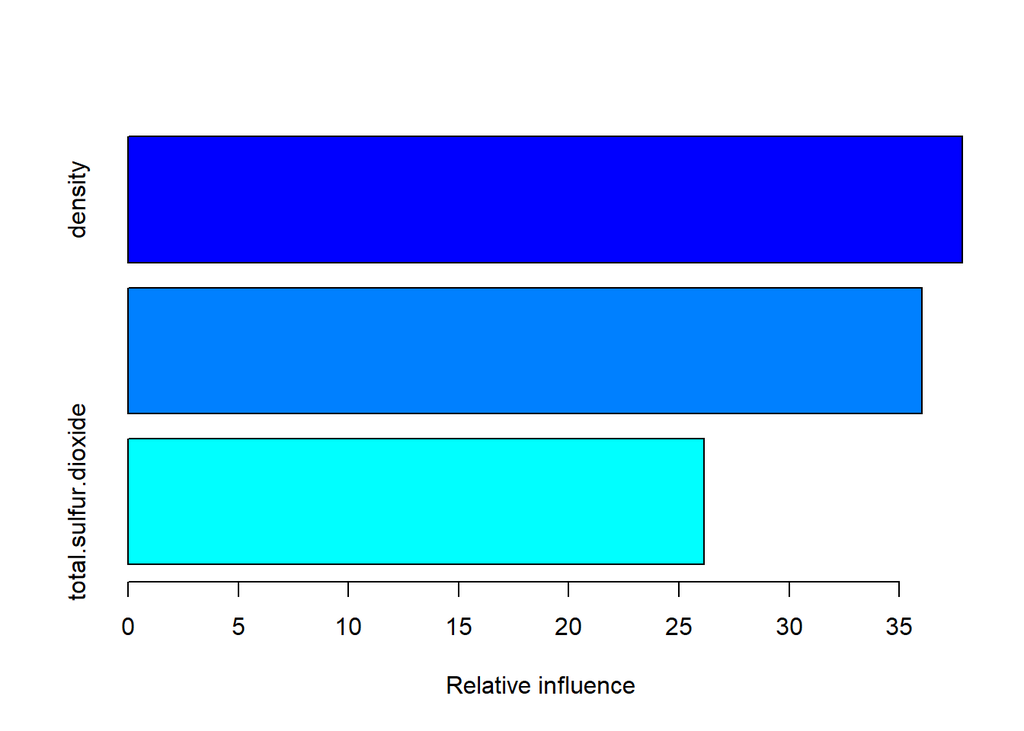

```
##                                       var  rel.inf
## density                           density 37.85038
## citric.acid                   citric.acid 36.00907
## total.sulfur.dioxide total.sulfur.dioxide 26.14055
```

```r
gbm.fit3 <- gbm(quality ~ density + citric.acid + total.sulfur.dioxide, data = df.Wine.Train, distribution = "gaussian", n.trees = 1000, interaction.depth = 3, shrinkage = 0.01, cv.folds = 5, verbose = T)
summary(gbm.fit3)
```

## Predicciones

```r
source("Lib.Preprocess.R")
set.seed(1991)
options(scipen = 999)
df.Wine <- read.csv(file = "WineQT.csv", header  = T, stringsAsFactors = F)
df.Wine$Id <-NULL

#Entrenamiento y prueba
Split <- sample.split(Y = df.Wine$alcohol, SplitRatio = 0.8)
df.Wine.Train <- subset(df.Wine, Split == T)
df.Wine.Test <- subset(df.Wine, Split == F)

#Modelos
mdl.Predict <- predict(object = gbm.fit, newdata = df.Wine.Test)
mdl.Predict2 <- predict(object = gbm.fit2, newdata = df.Wine.Test)
mdl.Predict3 <- predict(object = gbm.fit3, newdata = df.Wine.Test)

Y.pred <- ifelse(mdl.Predict >= 1.5 & mdl.Predict <= 2.5, 2,
                 ifelse(mdl.Predict > 2.5 & mdl.Predict <= 3.5, 3,
                        ifelse(mdl.Predict > 3.5 & mdl.Predict <= 4.5, 4,
                               ifelse(mdl.Predict > 4.5 & mdl.Predict <= 5.5, 5,
                                      ifelse(mdl.Predict > 5.5 & mdl.Predict <= 6.5, 6,
                                             ifelse(mdl.Predict > 6.5 & mdl.Predict <= 7.5, 7,
                                                    ifelse(mdl.Predict > 7.5 & mdl.Predict <= 8.5, 8, NA)))))))

Y.pred2 <- ifelse(mdl.Predict2 >= 1.5 & mdl.Predict2 <= 2.5, 2,
                 ifelse(mdl.Predict2 > 2.5 & mdl.Predict2 <= 3.5, 3,
                        ifelse(mdl.Predict2 > 3.5 & mdl.Predict2 <= 4.5, 4,
                               ifelse(mdl.Predict2 > 4.5 & mdl.Predict2 <= 5.5, 5,
                                      ifelse(mdl.Predict2 > 5.5 & mdl.Predict2 <= 6.5, 6,
                                             ifelse(mdl.Predict2 > 6.5 & mdl.Predict2 <= 7.5, 7,
                                                    ifelse(mdl.Predict2 > 7.5 & mdl.Predict2 <= 8.5, 8, NA)))))))

Y.pred3 <- ifelse(mdl.Predict3 >= 1.5 & mdl.Predict3 <= 2.5, 2,
                 ifelse(mdl.Predict3 > 2.5 & mdl.Predict3 <= 3.5, 3,
                        ifelse(mdl.Predict3 > 3.5 & mdl.Predict3 <= 4.5, 4,
                               ifelse(mdl.Predict3 > 4.5 & mdl.Predict3 <= 5.5, 5,
                                      ifelse(mdl.Predict3 > 5.5 & mdl.Predict3 <= 6.5, 6,
                                             ifelse(mdl.Predict3 > 6.5 & mdl.Predict3 <= 7.5, 7,
                                                    ifelse(mdl.Predict3 > 7.5 & mdl.Predict3 <= 8.5, 8, NA)))))))



matriz <- table(df.Wine.Test$quality, Y.pred)
matriz
```

```
##    Y.pred
##      5  6  7
##   3  1  0  0
##   4  2  2  0
##   5 71 27  0
##   6 29 55  6
##   7  0 13 10
##   8  0  3  3
```

```r
matriz2 <- table(df.Wine.Test$quality, Y.pred2)
matriz2
```

```
##    Y.pred2
##      5  6  7
##   3  1  0  0
##   4  2  2  0
##   5 70 28  0
##   6 33 55  2
##   7  0 17  6
##   8  0  3  3
```

```r
matriz3 <- table(df.Wine.Test$quality, Y.pred3)
matriz3
```

```
##    Y.pred3
##      5  6  7
##   3  1  0  0
##   4  2  2  0
##   5 55 42  1
##   6 31 51  8
##   7  0 22  1
##   8  0  5  1
```

## Gráfico de dispersión para los 3 modelos

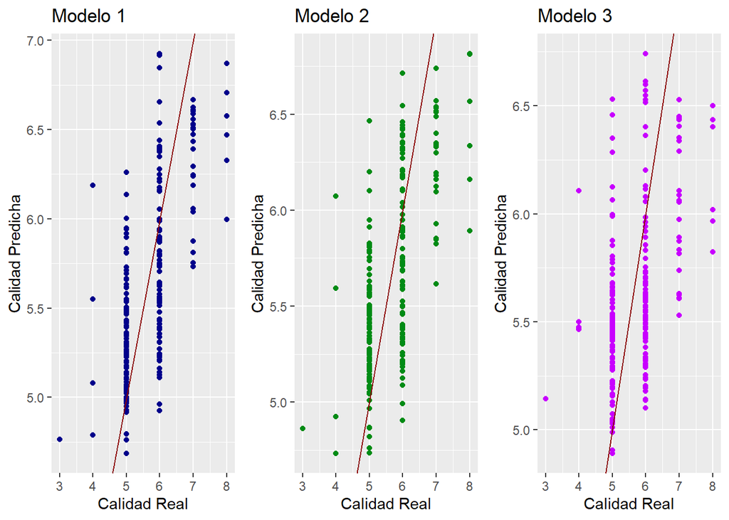

```r
source("Lib.Preprocess.R")
set.seed(1991)
options(scipen = 999)
df.Wine <- read.csv(file = "WineQT.csv", header  = T, stringsAsFactors = F)
df.Wine$Id <-NULL

#Entrenamiento y prueba
Split <- sample.split(Y = df.Wine$alcohol, SplitRatio = 0.8)
df.Wine.Train <- subset(df.Wine, Split == T)
df.Wine.Test <- subset(df.Wine, Split == F)

#Modelos
mdl.Predict <- predict(object = gbm.fit, newdata = df.Wine.Test)
mdl.Predict2 <- predict(object = gbm.fit2, newdata = df.Wine.Test)
mdl.Predict3 <- predict(object = gbm.fit3, newdata = df.Wine.Test)

# Crear un data frame con los valores reales y predichos para cada modelo
df_compare <- data.frame(
  Quality_Real = df.Wine.Test$quality,
  Quality_Predicted_Model1 = mdl.Predict,
  Quality_Predicted_Model2 = mdl.Predict2,
  Quality_Predicted_Model3 = mdl.Predict3
)

# Gráfico de dispersión para el primer modelo
p1 <- ggplot(df_compare, aes(x = Quality_Real, y = Quality_Predicted_Model1)) +
  geom_point(color = "darkblue") +
  geom_abline(intercept = 0, slope = 1, color = "darkred") +
  labs(title = "Modelo 1", x = "Calidad Real", y = "Calidad Predicha")

# Gráfico de dispersión para el segundo modelo
p2 <- ggplot(df_compare, aes(x = Quality_Real, y = Quality_Predicted_Model2)) +
  geom_point(color = "#008b15") +
  geom_abline(intercept = 0, slope = 1, color = "darkred") +
  labs(title = "Modelo 2", x = "Calidad Real", y = "Calidad Predicha")

# Gráfico de dispersión para el tercer modelo
p3 <- ggplot(df_compare, aes(x = Quality_Real, y = Quality_Predicted_Model3)) +
  geom_point(color = "#c800ff") +
  geom_abline(intercept = 0, slope = 1, color = "darkred") +
  labs(title = "Modelo 3", x = "Calidad Real", y = "Calidad Predicha")

# Combinar los tres gráficos en una cuadrícula
library(gridExtra)
grid.arrange(p1, p2, p3, ncol = 3)
```

## Conclusiones personales

#### Gómez Plascencia Waldo.

Fue bastante interesante ver el algoritmo aunque al final utilizamos gbm mediante una libreria, el proceso interno investigado es lo importante, donde pasan la evaluacion de los submodelos y son evaluados y ajustados para lograr un modelo decente. Asi mismo, nos costo un poco la limpieza de variables que al final no era necesaria por que con tantos datos atipicos intentamos ajustarlos de diferentes maneras a fin de de que no los hubiera, cuando nos percatamos que podiamos caer en un sobreajuste por intentarlo

#### Ascencio Padilla Isaac Ulises.

El algoritmo de gradient boostinng machine (gbm) es algo complicado para entenderlo completamente, principalmente por la complejidad del algoritmo, ya que implica una serie de pasos iterativos para ajustar múltiples modelos débiles y combinarlos en un modelo más robusto. Este algoritmo puede ser utilizado en la detección de fraudes, ya que puede detectar patrones anormales y acitividades fraudulentas en transacciones financieras y sistemas de seguridad.

#### Becerra Ramírez Alejandro.

Realmente no fue tan complicado comprender el algoritmo ya que es parecido a el de randomforest, pero en este caso de gbm lo que se busca de los árboles es que se vayan entrenando y que cada nuevo árbol vaya mejorando y quitando errores. Lo complicado fue más bien el escoger bien los hiperparámetros para no hacer un sobreajuste. A lo que investigué el gbm se utiliza en la predicción del fracaso empresarial, este algoritmo lo que hace es predecir que variables fueron las más relevantes para llegar a la quiebra, esto lo hacen utilizando datos como son las cifras de ventas, el activo y los gastos financieros.

#### Vidrio Lizaola Alfonso Manuel.

Al inicio, lo que más se me dificultó fue entender el funcionamiento del algoritmo y cómo lo podíamos implementar con los datos que teníamos. Pero con la librería gbm no fue tan complicado, y con un poco de investigación logré entender para qué son los parámetros que necesita gbm y un poco cómo es que funciona internamente.

#### Aceves Díaz César Alejandro.

Lo más complicado y tedioso fue la limpieza de variables debido a la cantidad de datos atípicos que existen en todas las variables. No estabamos seguros de que se debía hacer en ese caso: si eliminar filas de registros, ajustarlos o simplmente ignorarlos y realizar el modelo con el dataset original. Al utilizar GBM como librería para nuestro algoritmo, resulto fácil hacer la implementación y obtener resultados.